# Linear Regression on Airbnb Dataset

This is a dataset of AirBnb having 29 columns. Aim of this linear regression is to predict the price of room from given features.

```python
from IPython.display import Image
from IPython.core.display import HTML
Image(url= "https://fortunedotcom.files.wordpress.com/2014/07/new-logos-airbnb.jpg")
```

# Load Libraries

```python
import pandas as pd
from sklearn.model_selection import cross_val_score
from sklearn.metrics import mean_squared_error, make_scorer
from sklearn.linear_model import LinearRegression
from sklearn import linear_model
import seaborn as sns
import statsmodels.api as sm
import statsmodels as statm
from statsmodels.formula.api import ols
from sklearn.linear_model import LinearRegression
import matplotlib.pyplot as plt
import seaborn as sns
import numpy as np
from plotnine import *
```

# Load File

```python
filedata= pd.read_csv('../input/train.csv')
```

# Exploratory Data Analysis(EDA)

## File structure and content

```python
filedata.head(5)
```

|  | id | log_price | property_type | room_type | amenities | accommodates | bathrooms | bed_type | cancellation_policy | cleaning_fee | city | description | first_review | host_has_profile_pic | host_identity_verified | host_response_rate | host_since | instant_bookable | last_review | latitude | longitude | name | neighbourhood | number_of_reviews | review_scores_rating | thumbnail_url | zipcode | bedrooms | beds |
| --- | --- | --- | --- | --- | --- | --- | --- | --- | --- | --- | --- | --- | --- | --- | --- | --- | --- | --- | --- | --- | --- | --- | --- | --- | --- | --- | --- | --- | --- |
| 0 | 6901257 | 5.010635 | Apartment | Entire home/apt | {"Wireless Internet","Air conditioning",Kitche... | 3 | 1.0 | Real Bed | strict | True | NYC | Beautiful, sunlit brownstone 1-bedroom in the ... | 2016-06-18 | t | t | NaN | 2012-03-26 | f | 2016-07-18 | 40.696524 | -73.991617 | Beautiful brownstone 1-bedroom | Brooklyn Heights | 2 | 100.0 | https://a0.muscache.com/im/pictures/6d7cbbf7-c... | 11201 | 1.0 | 1.0 |
| 1 | 6304928 | 5.129899 | Apartment | Entire home/apt | {"Wireless Internet","Air conditioning",Kitche... | 7 | 1.0 | Real Bed | strict | True | NYC | Enjoy travelling during your stay in Manhattan... | 2017-08-05 | t | f | 100% | 2017-06-19 | t | 2017-09-23 | 40.766115 | -73.989040 | Superb 3BR Apt Located Near Times Square | Hell's Kitchen | 6 | 93.0 | https://a0.muscache.com/im/pictures/348a55fe-4... | 10019 | 3.0 | 3.0 |
| 2 | 7919400 | 4.976734 | Apartment | Entire home/apt | {TV,"Cable TV","Wireless Internet","Air condit... | 5 | 1.0 | Real Bed | moderate | True | NYC | The Oasis comes complete with a full backyard ... | 2017-04-30 | t | t | 100% | 2016-10-25 | t | 2017-09-14 | 40.808110 | -73.943756 | The Garden Oasis | Harlem | 10 | 92.0 | https://a0.muscache.com/im/pictures/6fae5362-9... | 10027 | 1.0 | 3.0 |
| 3 | 13418779 | 6.620073 | House | Entire home/apt | {TV,"Cable TV",Internet,"Wireless Internet",Ki... | 4 | 1.0 | Real Bed | flexible | True | SF | This light-filled home-away-from-home is super... | NaN | t | t | NaN | 2015-04-19 | f | NaN | 37.772004 | -122.431619 | Beautiful Flat in the Heart of SF! | Lower Haight | 0 | NaN | https://a0.muscache.com/im/pictures/72208dad-9... | 94117.0 | 2.0 | 2.0 |
| 4 | 3808709 | 4.744932 | Apartment | Entire home/apt | {TV,Internet,"Wireless Internet","Air conditio... | 2 | 1.0 | Real Bed | moderate | True | DC | Cool, cozy, and comfortable studio located in ... | 2015-05-12 | t | t | 100% | 2015-03-01 | t | 2017-01-22 | 38.925627 | -77.034596 | Great studio in midtown DC | Columbia Heights | 4 | 40.0 | NaN | 20009 | 0.0 | 1.0 |

```python
len(filedata.columns)
```

```
29
```

```python
filedata.shape
```

```
(74111, 29)
```

```python
filedata.info()
```

```
<class 'pandas.core.frame.DataFrame'>
RangeIndex: 74111 entries, 0 to 74110
Data columns (total 29 columns):
id                        74111 non-null int64
log_price                 74111 non-null float64
property_type             74111 non-null object
room_type                 74111 non-null object
amenities                 74111 non-null object
accommodates              74111 non-null int64
bathrooms                 73911 non-null float64
bed_type                  74111 non-null object
cancellation_policy       74111 non-null object
cleaning_fee              74111 non-null bool
city                      74111 non-null object
description               74111 non-null object
first_review              58247 non-null object
host_has_profile_pic      73923 non-null object
host_identity_verified    73923 non-null object
host_response_rate        55812 non-null object
host_since                73923 non-null object
instant_bookable          74111 non-null object
last_review               58284 non-null object
latitude                  74111 non-null float64
longitude                 74111 non-null float64
name                      74111 non-null object
neighbourhood             67239 non-null object
number_of_reviews         74111 non-null int64
review_scores_rating      57389 non-null float64
thumbnail_url             65895 non-null object
zipcode                   73145 non-null object
bedrooms                  74020 non-null float64
beds                      73980 non-null float64
dtypes: bool(1), float64(7), int64(3), object(18)
memory usage: 15.9+ MB
```

```python
#check for missing data, and output columns that have missing data
for col in filedata:
    if (filedata[col].isnull().any()):
        print(col)
```

```
bathrooms
first_review
host_has_profile_pic
host_identity_verified
host_response_rate
host_since
last_review
neighbourhood
review_scores_rating
thumbnail_url
zipcode
bedrooms
beds
```

```python
#fills missing data with 0s
#GO BACK TO THIS, 0 may not be best fill for all missing data
filedata=filedata.fillna(0)
```

```python
#summary stats on each of the numeric columns
filedata.describe()
```

|  | id | log_price | accommodates | bathrooms | latitude | longitude | number_of_reviews | review_scores_rating | bedrooms | beds |
| --- | --- | --- | --- | --- | --- | --- | --- | --- | --- | --- |
| count | 7.411100e+04 | 74111.000000 | 74111.000000 | 74111.000000 | 74111.000000 | 74111.000000 | 74111.000000 | 74111.000000 | 74111.000000 | 74111.000000 |
| mean | 1.126662e+07 | 4.782069 | 3.155146 | 1.231929 | 38.445958 | -92.397525 | 20.900568 | 72.842520 | 1.264239 | 1.707844 |
| std | 6.081735e+06 | 0.717394 | 2.153589 | 0.584780 | 3.080167 | 21.705322 | 37.828641 | 39.920507 | 0.852773 | 1.255092 |
| min | 3.440000e+02 | 0.000000 | 1.000000 | 0.000000 | 33.338905 | -122.511500 | 0.000000 | 0.000000 | 0.000000 | 0.000000 |
| 25% | 6.261964e+06 | 4.317488 | 2.000000 | 1.000000 | 34.127908 | -118.342374 | 1.000000 | 80.000000 | 1.000000 | 1.000000 |
| 50% | 1.225415e+07 | 4.709530 | 2.000000 | 1.000000 | 40.662138 | -76.996965 | 6.000000 | 94.000000 | 1.000000 | 1.000000 |
| 75% | 1.640226e+07 | 5.220356 | 4.000000 | 1.000000 | 40.746096 | -73.954660 | 23.000000 | 99.000000 | 1.000000 | 2.000000 |
| max | 2.123090e+07 | 7.600402 | 16.000000 | 8.000000 | 42.390437 | -70.985047 | 605.000000 | 100.000000 | 10.000000 | 18.000000 |

```python
#check all the statistics
filedata.describe(include='all')
```

|  | id | log_price | property_type | room_type | amenities | accommodates | bathrooms | bed_type | cancellation_policy | cleaning_fee | city | description | first_review | host_has_profile_pic | host_identity_verified | host_response_rate | host_since | instant_bookable | last_review | latitude | longitude | name | neighbourhood | number_of_reviews | review_scores_rating | thumbnail_url | zipcode | bedrooms | beds |
| --- | --- | --- | --- | --- | --- | --- | --- | --- | --- | --- | --- | --- | --- | --- | --- | --- | --- | --- | --- | --- | --- | --- | --- | --- | --- | --- | --- | --- | --- |
| count | 7.411100e+04 | 74111.000000 | 74111 | 74111 | 74111 | 74111.000000 | 74111.000000 | 74111 | 74111 | 74111 | 74111 | 74111 | 74111.0 | 74111 | 74111 | 74111 | 74111 | 74111 | 74111.0 | 74111.000000 | 74111.000000 | 74111 | 74111.0 | 74111.000000 | 74111.000000 | 74111.0 | 74111 | 74111.000000 | 74111.000000 |
| unique | NaN | NaN | 35 | 3 | 67122 | NaN | NaN | 5 | 5 | 2 | 6 | 73479 | 2555.0 | 3 | 3 | 81 | 3088 | 2 | 1372.0 | NaN | NaN | 73359 | 620.0 | NaN | NaN | 65884.0 | 770 | NaN | NaN |
| top | NaN | NaN | Apartment | Entire home/apt | {} | NaN | NaN | Real Bed | strict | True | NYC | Hello, I've been running guest house for Korea... | 0.0 | t | t | 100% | 2015-03-30 | f | 0.0 | NaN | NaN | Bunk bed in the Treat Street Clubhouse | 0.0 | NaN | NaN | 0.0 | 11211.0 | NaN | NaN |
| freq | NaN | NaN | 49003 | 41310 | 586 | NaN | NaN | 72028 | 32374 | 54403 | 32349 | 8 | 15864.0 | 73697 | 49748 | 43254 | 246 | 54660 | 15827.0 | NaN | NaN | 8 | 6872.0 | NaN | NaN | 8216.0 | 1368 | NaN | NaN |
| mean | 1.126662e+07 | 4.782069 | NaN | NaN | NaN | 3.155146 | 1.231929 | NaN | NaN | NaN | NaN | NaN | NaN | NaN | NaN | NaN | NaN | NaN | NaN | 38.445958 | -92.397525 | NaN | NaN | 20.900568 | 72.842520 | NaN | NaN | 1.264239 | 1.707844 |
| std | 6.081735e+06 | 0.717394 | NaN | NaN | NaN | 2.153589 | 0.584780 | NaN | NaN | NaN | NaN | NaN | NaN | NaN | NaN | NaN | NaN | NaN | NaN | 3.080167 | 21.705322 | NaN | NaN | 37.828641 | 39.920507 | NaN | NaN | 0.852773 | 1.255092 |
| min | 3.440000e+02 | 0.000000 | NaN | NaN | NaN | 1.000000 | 0.000000 | NaN | NaN | NaN | NaN | NaN | NaN | NaN | NaN | NaN | NaN | NaN | NaN | 33.338905 | -122.511500 | NaN | NaN | 0.000000 | 0.000000 | NaN | NaN | 0.000000 | 0.000000 |
| 25% | 6.261964e+06 | 4.317488 | NaN | NaN | NaN | 2.000000 | 1.000000 | NaN | NaN | NaN | NaN | NaN | NaN | NaN | NaN | NaN | NaN | NaN | NaN | 34.127908 | -118.342374 | NaN | NaN | 1.000000 | 80.000000 | NaN | NaN | 1.000000 | 1.000000 |
| 50% | 1.225415e+07 | 4.709530 | NaN | NaN | NaN | 2.000000 | 1.000000 | NaN | NaN | NaN | NaN | NaN | NaN | NaN | NaN | NaN | NaN | NaN | NaN | 40.662138 | -76.996965 | NaN | NaN | 6.000000 | 94.000000 | NaN | NaN | 1.000000 | 1.000000 |
| 75% | 1.640226e+07 | 5.220356 | NaN | NaN | NaN | 4.000000 | 1.000000 | NaN | NaN | NaN | NaN | NaN | NaN | NaN | NaN | NaN | NaN | NaN | NaN | 40.746096 | -73.954660 | NaN | NaN | 23.000000 | 99.000000 | NaN | NaN | 1.000000 | 2.000000 |
| max | 2.123090e+07 | 7.600402 | NaN | NaN | NaN | 16.000000 | 8.000000 | NaN | NaN | NaN | NaN | NaN | NaN | NaN | NaN | NaN | NaN | NaN | NaN | 42.390437 | -70.985047 | NaN | NaN | 605.000000 | 100.000000 | NaN | NaN | 10.000000 | 18.000000 |

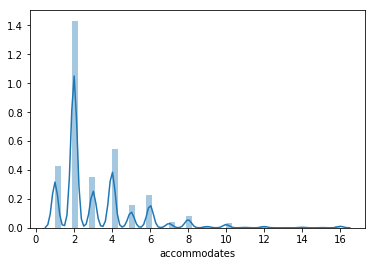

```python
numerics = ['int16', 'int32', 'int64', 'float16', 'float32', 'float64','uint8']
numericdataX = filedata.select_dtypes(include=numerics)
x= numericdataX['accommodates']
sns.distplot(x);
```

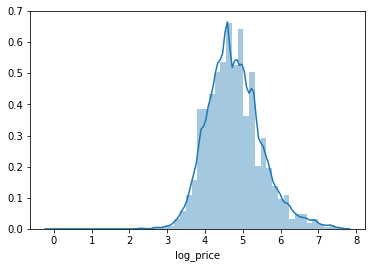

```python
x= numericdataX.iloc[:,1]
sns.distplot(x);
```

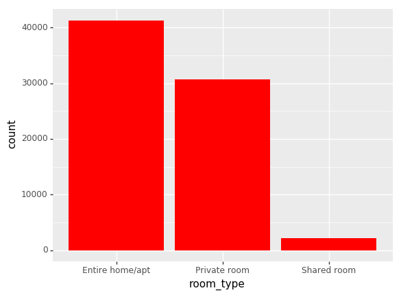

```python
ggplot(filedata, aes(x='room_type')) + geom_bar(fill = "red")
```

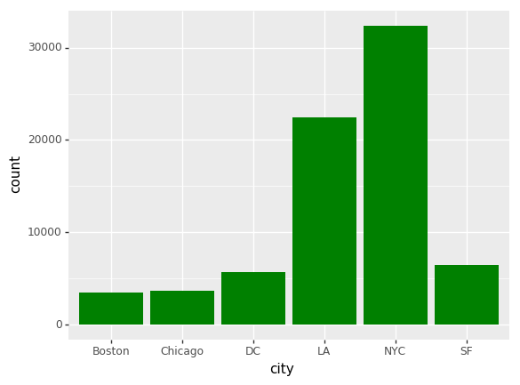

```python
ggplot(filedata, aes(x='city')) + geom_bar(fill = "green")
```

```python
#check categorical data
filedata.describe(include=['O'])
```

|  | property_type | room_type | amenities | bed_type | cancellation_policy | city | description | first_review | host_has_profile_pic | host_identity_verified | host_response_rate | host_since | instant_bookable | last_review | name | neighbourhood | thumbnail_url | zipcode |
| --- | --- | --- | --- | --- | --- | --- | --- | --- | --- | --- | --- | --- | --- | --- | --- | --- | --- | --- |
| count | 74111 | 74111 | 74111 | 74111 | 74111 | 74111 | 74111 | 74111 | 74111 | 74111 | 74111 | 74111 | 74111 | 74111 | 74111 | 74111 | 74111 | 74111 |
| unique | 35 | 3 | 67122 | 5 | 5 | 6 | 73479 | 2555 | 3 | 3 | 81 | 3088 | 2 | 1372 | 73359 | 620 | 65884 | 770 |
| top | Apartment | Entire home/apt | {} | Real Bed | strict | NYC | Hello, I've been running guest house for Korea... | 0 | t | t | 100% | 2015-03-30 | f | 0 | Bunk bed in the Treat Street Clubhouse | 0 | 0 | 11211.0 |
| freq | 49003 | 41310 | 586 | 72028 | 32374 | 32349 | 8 | 15864 | 73697 | 49748 | 43254 | 246 | 54660 | 15827 | 8 | 6872 | 8216 | 1368 |

```python
#check numeric data
filedata.describe()
```

|  | id | log_price | accommodates | bathrooms | latitude | longitude | number_of_reviews | review_scores_rating | bedrooms | beds |
| --- | --- | --- | --- | --- | --- | --- | --- | --- | --- | --- |
| count | 7.411100e+04 | 74111.000000 | 74111.000000 | 74111.000000 | 74111.000000 | 74111.000000 | 74111.000000 | 74111.000000 | 74111.000000 | 74111.000000 |
| mean | 1.126662e+07 | 4.782069 | 3.155146 | 1.231929 | 38.445958 | -92.397525 | 20.900568 | 72.842520 | 1.264239 | 1.707844 |
| std | 6.081735e+06 | 0.717394 | 2.153589 | 0.584780 | 3.080167 | 21.705322 | 37.828641 | 39.920507 | 0.852773 | 1.255092 |
| min | 3.440000e+02 | 0.000000 | 1.000000 | 0.000000 | 33.338905 | -122.511500 | 0.000000 | 0.000000 | 0.000000 | 0.000000 |
| 25% | 6.261964e+06 | 4.317488 | 2.000000 | 1.000000 | 34.127908 | -118.342374 | 1.000000 | 80.000000 | 1.000000 | 1.000000 |
| 50% | 1.225415e+07 | 4.709530 | 2.000000 | 1.000000 | 40.662138 | -76.996965 | 6.000000 | 94.000000 | 1.000000 | 1.000000 |
| 75% | 1.640226e+07 | 5.220356 | 4.000000 | 1.000000 | 40.746096 | -73.954660 | 23.000000 | 99.000000 | 1.000000 | 2.000000 |
| max | 2.123090e+07 | 7.600402 | 16.000000 | 8.000000 | 42.390437 | -70.985047 | 605.000000 | 100.000000 | 10.000000 | 18.000000 |

```python
filedata.columns
```

```
Index(['id', 'log_price', 'property_type', 'room_type', 'amenities',
       'accommodates', 'bathrooms', 'bed_type', 'cancellation_policy',
       'cleaning_fee', 'city', 'description', 'first_review',
       'host_has_profile_pic', 'host_identity_verified', 'host_response_rate',
       'host_since', 'instant_bookable', 'last_review', 'latitude',
       'longitude', 'name', 'neighbourhood', 'number_of_reviews',
       'review_scores_rating', 'thumbnail_url', 'zipcode', 'bedrooms', 'beds'],
      dtype='object')
```

# Linear Assumptions

## Assumption that data point are linearly disributed

[output not shown]

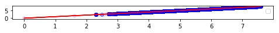

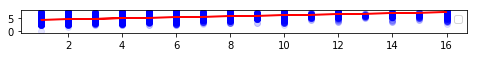

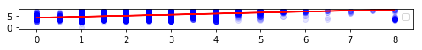

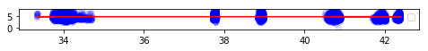

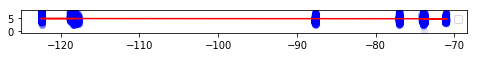

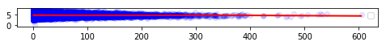

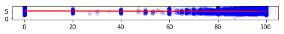

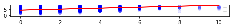

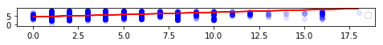

```python
regressor = linear_model.LinearRegression()
for i in range(1,10):
    x= np.array(numericdataX.iloc[:,i]).reshape(-1,1)
    y= np.array(filedata['log_price']).reshape(-1,1)
    regressor.fit(x,y)
    plt.figure(figsize=(8,5))
    plt.subplot(10,1,i)
    plt.scatter(x,y,color='blue', alpha=0.1)
    plt.plot(x,regressor.predict(x),color="red")
    plt.legend()
```

## Q-Q plot

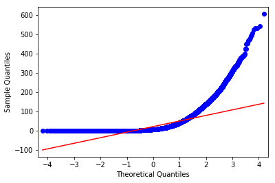

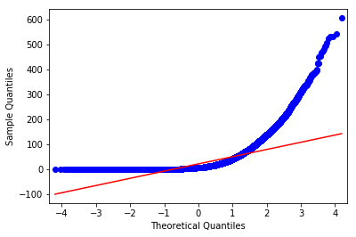

```python
statm.graphics.gofplots.qqplot(numericdataX.iloc[:,6], line='r')
```

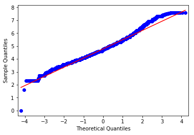

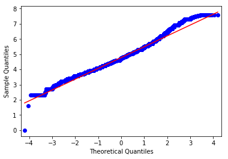

```python
statm.graphics.gofplots.qqplot(numericdataX.iloc[:,1], line='r')
```

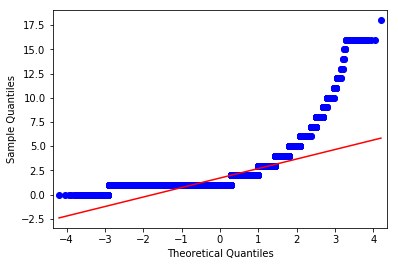

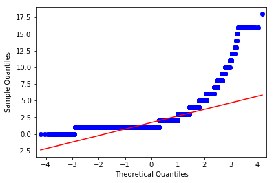

```python
statm.graphics.gofplots.qqplot(numericdataX.iloc[:,9], line='r')
```

# Linear Regression

### Functions

```python
def checkCorrelation(data):
    """
    Plot correlation Matrix for given data
   :param data: dataset having features
   :return: return plot representing pearson correlation
   """
    plt.figure(figsize=(20, 20))
    sns.heatmap(data.corr(),linewidths=0.25,vmax=1.0,square=True,cmap="BuGn_r",
    linecolor='w',annot=True)
```

```python
#return Model
def data_model(xdata):
    """
     fits linear regression model on given data
    :param xdata: independent variable dataset
    :return: linear regression model with fit of xdata
   """
    #add constant to data
    X = sm.add_constant(xdata)
    targetY=filedata[['log_price']]
    y = targetY

    # Fit the linear model
    model = linear_model.LinearRegression()
    results = model.fit(X, y)
    model = sm.OLS(y, X)
    results = model.fit()
    return results
```

```python
def data_summary(xdata):
    """
    Returns chart having summary of data
   :param xdata: independent variable dataset
   :return: summary of data
   """
    results = data_model(xdata)
    return results.summary()
```

```python
def crossValidationError(data):
    """
   Finds cross validation error of model
   :param X: independent variable dataset
   :return: float value returns mean squared error
   """
    numericdataX=data
    X = np.array(numericdataX.drop(['log_price'],axis=1), dtype=pd.Series)
    Y = np.array(numericdataX['log_price'], dtype=pd.Series)
    regr1 = linear_model.LinearRegression()
    ms_errors= cross_val_score(regr1, X, Y, cv=5, scoring = make_scorer(mean_squared_error))
    rms_errors = np.sqrt(ms_errors)
    mean_rms_error = rms_errors.mean()
    return mean_rms_error
```

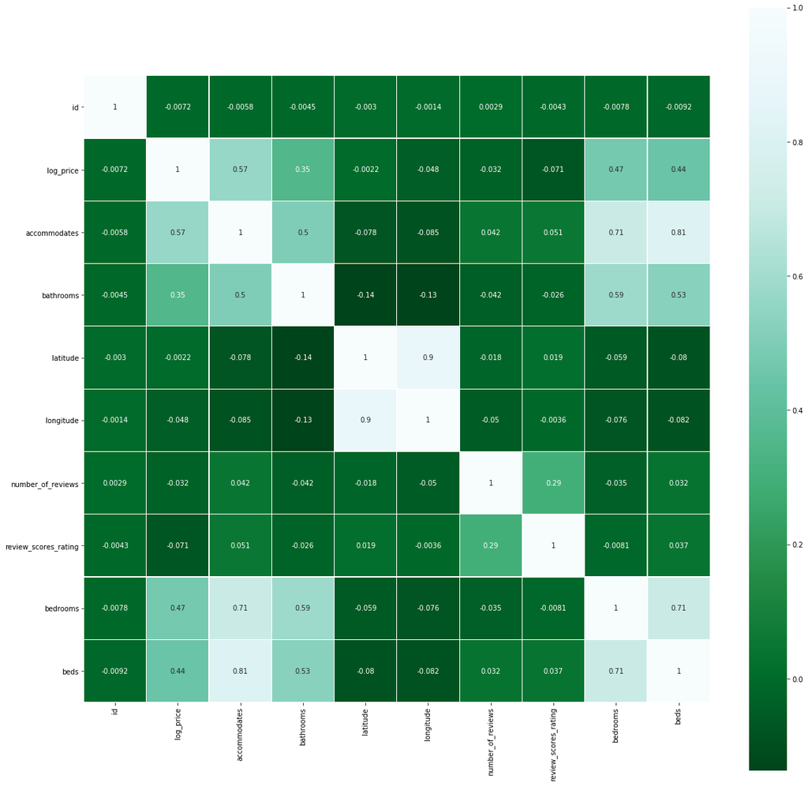

```python
#Checking correlation in data
checkCorrelation(numericdataX)
```

```python
#So as per correlation matrix colums such as latitude, longitude, number_of_reviews and review_scores_rating are not making much impact on log_price
#as valueof cirrelation is poor
#lets drop them from our dataset
numericdataX=numericdataX.drop(['id','number_of_reviews',
       'review_scores_rating','latitude',
       'longitude' ], axis=1)
```

```python
# buid model and check summary
data_summary(numericdataX)
```

OLS Regression Results

| Dep. Variable: | log_price | R-squared: | 1.000 |
| --- | --- | --- | --- |
| Model: | OLS | Adj. R-squared: | 1.000 |
| Method: | Least Squares | F-statistic: | 1.577e+32 |
| Date: | Sat, 08 Dec 2018 | Prob (F-statistic): | 0.00 |
| Time: | 07:11:19 | Log-Likelihood: | 2.3108e+06 |
| No. Observations: | 74111 | AIC: | -4.622e+06 |
| Df Residuals: | 74105 | BIC: | -4.622e+06 |
| Df Model: | 5 |  |  |
| Covariance Type: | nonrobust |  |  |

|  | coef | std err | t | P>\|t\| | [0.025 | 0.975] |
| --- | --- | --- | --- | --- | --- | --- |
| const | 5.96e-16 | 1.89e-16 | 3.150 | 0.002 | 2.25e-16 | 9.67e-16 |
| log_price | 1.0000 | 4.38e-17 | 2.28e+16 | 0.000 | 1.000 | 1.000 |
| accommodates | -1.506e-16 | 2.28e-17 | -6.603 | 0.000 | -1.95e-16 | -1.06e-16 |
| bathrooms | 1.42e-16 | 5.52e-17 | 2.575 | 0.010 | 3.39e-17 | 2.5e-16 |
| bedrooms | 3.04e-16 | 4.78e-17 | 6.355 | 0.000 | 2.1e-16 | 3.98e-16 |
| beds | -2.035e-16 | 3.71e-17 | -5.482 | 0.000 | -2.76e-16 | -1.31e-16 |

| Omnibus: | 3706.026 | Durbin-Watson: | 0.067 |
| --- | --- | --- | --- |
| Prob(Omnibus): | 0.000 | Jarque-Bera (JB): | 4700.921 |
| Skew: | 0.510 | Prob(JB): | 0.00 |
| Kurtosis: | 3.695 | Cond. No. | 50.3 |

Warnings:  
[1] Standard Errors assume that the covariance matrix of the errors is correctly specified.

```python
# there is also correlation between bathroom and accomodates and bedroom lets only keep acomodates
numericdataX = numericdataX.drop(['bathrooms','bedrooms','beds'], axis=1)
```

```python
# buid model and check summary
data_summary(numericdataX)
```

OLS Regression Results

| Dep. Variable: | log_price | R-squared: | 1.000 |
| --- | --- | --- | --- |
| Model: | OLS | Adj. R-squared: | 1.000 |
| Method: | Least Squares | F-statistic: | 3.660e+32 |
| Date: | Sat, 08 Dec 2018 | Prob (F-statistic): | 0.00 |
| Time: | 07:11:19 | Log-Likelihood: | 2.3081e+06 |
| No. Observations: | 74111 | AIC: | -4.616e+06 |
| Df Residuals: | 74108 | BIC: | -4.616e+06 |
| Df Model: | 2 |  |  |
| Covariance Type: | nonrobust |  |  |

|  | coef | std err | t | P>\|t\| | [0.025 | 0.975] |
| --- | --- | --- | --- | --- | --- | --- |
| const | -8.484e-15 | 1.94e-16 | -43.798 | 0.000 | -8.86e-15 | -8.1e-15 |
| log_price | 1.0000 | 4.49e-17 | 2.23e+16 | 0.000 | 1.000 | 1.000 |
| accommodates | -1.863e-16 | 1.5e-17 | -12.455 | 0.000 | -2.16e-16 | -1.57e-16 |

| Omnibus: | 3562.244 | Durbin-Watson: | 0.011 |
| --- | --- | --- | --- |
| Prob(Omnibus): | 0.000 | Jarque-Bera (JB): | 5412.252 |
| Skew: | 0.433 | Prob(JB): | 0.00 |
| Kurtosis: | 4.001 | Cond. No. | 45.2 |

Warnings:  
[1] Standard Errors assume that the covariance matrix of the errors is correctly specified.

```python
crossValidationError(numericdataX)
```

```
0.5906434455693735
```

## Handling Categorical Variables

```python
filedata.room_type.value_counts()
```

```
Entire home/apt    41310
Private room       30638
Shared room         2163
Name: room_type, dtype: int64
```

```python
#creating dummy variable for column room_type
numericdataX=pd.concat([numericdataX,filedata['room_type']], axis=1)
numericdataX=pd.get_dummies(numericdataX,columns= ['room_type'],drop_first=True)
```

```python
numericdataX
```

|  | log_price | accommodates | room_type_Private room | room_type_Shared room |
| --- | --- | --- | --- | --- |
| 0 | 5.010635 | 3 | 0 | 0 |
| 1 | 5.129899 | 7 | 0 | 0 |
| 2 | 4.976734 | 5 | 0 | 0 |
| 3 | 6.620073 | 4 | 0 | 0 |
| 4 | 4.744932 | 2 | 0 | 0 |
| 5 | 4.442651 | 2 | 1 | 0 |
| 6 | 4.418841 | 3 | 0 | 0 |
| 7 | 4.787492 | 2 | 0 | 0 |
| 8 | 4.787492 | 2 | 1 | 0 |
| 9 | 3.583519 | 2 | 1 | 0 |
| 10 | 4.605170 | 2 | 1 | 0 |
| 11 | 5.010635 | 4 | 0 | 0 |
| 12 | 4.248495 | 2 | 1 | 0 |
| 13 | 5.298317 | 6 | 0 | 0 |
| 14 | 4.955827 | 2 | 0 | 0 |
| 15 | 4.094345 | 2 | 1 | 0 |
| 16 | 4.317488 | 2 | 1 | 0 |
| 17 | 4.595120 | 2 | 1 | 0 |
| 18 | 4.882802 | 2 | 0 | 0 |
| 19 | 4.595120 | 8 | 0 | 0 |
| 20 | 4.382027 | 2 | 1 | 0 |
| 21 | 3.688879 | 2 | 1 | 0 |
| 22 | 4.905275 | 4 | 0 | 0 |
| 23 | 4.007333 | 2 | 1 | 0 |
| 24 | 6.956545 | 4 | 0 | 0 |
| 25 | 5.003946 | 6 | 0 | 0 |
| 26 | 4.553877 | 2 | 0 | 0 |
| 27 | 5.003946 | 4 | 0 | 0 |
| 28 | 5.192957 | 3 | 0 | 0 |
| 29 | 4.653960 | 3 | 1 | 0 |
| ... | ... | ... | ... | ... |
| 74081 | 6.907755 | 16 | 0 | 0 |
| 74082 | 4.174387 | 1 | 1 | 0 |
| 74083 | 5.010635 | 2 | 1 | 0 |
| 74084 | 5.843544 | 4 | 0 | 0 |
| 74085 | 4.653960 | 2 | 0 | 0 |
| 74086 | 4.174387 | 2 | 1 | 0 |
| 74087 | 4.477337 | 4 | 0 | 0 |
| 74088 | 4.905275 | 5 | 0 | 0 |
| 74089 | 4.605170 | 2 | 1 | 0 |
| 74090 | 4.317488 | 2 | 1 | 0 |
| 74091 | 5.010635 | 2 | 0 | 0 |
| 74092 | 4.700480 | 4 | 0 | 0 |
| 74093 | 4.948760 | 4 | 0 | 0 |
| 74094 | 3.688879 | 2 | 1 | 0 |
| 74095 | 4.382027 | 2 | 0 | 0 |
| 74096 | 3.912023 | 2 | 1 | 0 |
| 74097 | 4.700480 | 2 | 1 | 0 |
| 74098 | 4.553877 | 4 | 0 | 0 |
| 74099 | 4.276666 | 2 | 1 | 0 |
| 74100 | 4.605170 | 2 | 1 | 0 |
| 74101 | 4.584967 | 1 | 1 | 0 |
| 74102 | 4.110874 | 10 | 0 | 1 |
| 74103 | 5.135798 | 2 | 0 | 0 |
| 74104 | 4.356709 | 2 | 0 | 0 |
| 74105 | 4.248495 | 2 | 1 | 0 |
| 74106 | 4.605170 | 1 | 1 | 0 |
| 74107 | 5.043425 | 4 | 0 | 0 |
| 74108 | 5.220356 | 5 | 0 | 0 |
| 74109 | 5.273000 | 2 | 0 | 0 |
| 74110 | 4.852030 | 4 | 0 | 0 |

74111 rows × 4 columns

```python
filedata.bed_type.value_counts()
```

```
Real Bed         72028
Futon              753
Pull-out Sofa      585
Airbed             477
Couch              268
Name: bed_type, dtype: int64
```

```python
numericdataX=pd.concat([numericdataX,filedata['bed_type']], axis=1)
numericdataX=pd.get_dummies(numericdataX,columns=['bed_type'],drop_first=True)
```

```python
filedata.cancellation_policy.value_counts()
```

```
strict             32374
flexible           22545
moderate           19063
super_strict_30      112
super_strict_60       17
Name: cancellation_policy, dtype: int64
```

```python
numericdataX=pd.concat([numericdataX,filedata['cancellation_policy']], axis=1)
numericdataX=pd.get_dummies(numericdataX,columns=['cancellation_policy'],drop_first=True)
```

```python
filedata.city.value_counts()
```

```
NYC        32349
LA         22453
SF          6434
DC          5688
Chicago     3719
Boston      3468
Name: city, dtype: int64
```

```python
numericdataX=pd.concat([numericdataX,filedata['city']], axis=1)
numericdataX=pd.get_dummies(numericdataX,columns=['city'],drop_first=True)
```

```python
filedata.instant_bookable.value_counts()
numericdataX=pd.concat([numericdataX,filedata['instant_bookable']], axis=1)
numericdataX=pd.get_dummies(numericdataX,columns=['instant_bookable'],drop_first=True)
```

# Multicolinearity

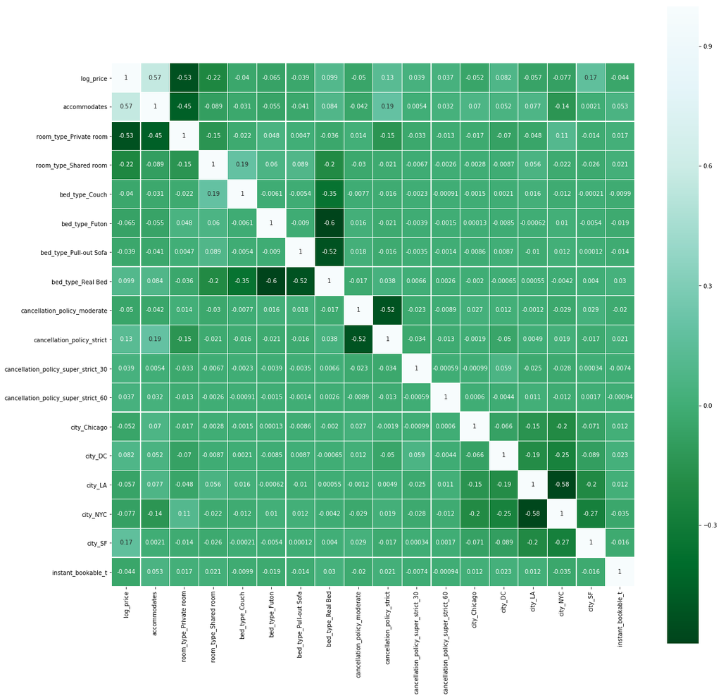

```python
checkCorrelation(numericdataX)
```

```python
data_summary(numericdataX.drop(['log_price'],axis=1))
```

OLS Regression Results

| Dep. Variable: | log_price | R-squared: | 0.516 |
| --- | --- | --- | --- |
| Model: | OLS | Adj. R-squared: | 0.516 |
| Method: | Least Squares | F-statistic: | 4652. |
| Date: | Sat, 08 Dec 2018 | Prob (F-statistic): | 0.00 |
| Time: | 07:11:21 | Log-Likelihood: | -53631. |
| No. Observations: | 74111 | AIC: | 1.073e+05 |
| Df Residuals: | 74093 | BIC: | 1.075e+05 |
| Df Model: | 17 |  |  |
| Covariance Type: | nonrobust |  |  |

|  | coef | std err | t | P>\|t\| | [0.025 | 0.975] |
| --- | --- | --- | --- | --- | --- | --- |
| const | 4.7122 | 0.025 | 189.245 | 0.000 | 4.663 | 4.761 |
| accommodates | 0.1268 | 0.001 | 127.763 | 0.000 | 0.125 | 0.129 |
| room_type_Private room | -0.5762 | 0.004 | -133.420 | 0.000 | -0.585 | -0.568 |
| room_type_Shared room | -1.0229 | 0.012 | -88.508 | 0.000 | -1.046 | -1.000 |
| bed_type_Couch | 0.1592 | 0.038 | 4.156 | 0.000 | 0.084 | 0.234 |
| bed_type_Futon | -0.0229 | 0.029 | -0.783 | 0.433 | -0.080 | 0.034 |
| bed_type_Pull-out Sofa | 0.0263 | 0.031 | 0.853 | 0.394 | -0.034 | 0.087 |
| bed_type_Real Bed | 0.0479 | 0.023 | 2.079 | 0.038 | 0.003 | 0.093 |
| cancellation_policy_moderate | -0.0893 | 0.005 | -18.061 | 0.000 | -0.099 | -0.080 |
| cancellation_policy_strict | -0.0451 | 0.004 | -10.128 | 0.000 | -0.054 | -0.036 |
| cancellation_policy_super_strict_30 | 0.2908 | 0.047 | 6.128 | 0.000 | 0.198 | 0.384 |
| cancellation_policy_super_strict_60 | 0.8926 | 0.121 | 7.367 | 0.000 | 0.655 | 1.130 |
| city_Chicago | -0.3080 | 0.012 | -26.082 | 0.000 | -0.331 | -0.285 |
| city_DC | 0.0340 | 0.011 | 3.158 | 0.002 | 0.013 | 0.055 |
| city_LA | -0.1448 | 0.009 | -15.855 | 0.000 | -0.163 | -0.127 |
| city_NYC | -0.0374 | 0.009 | -4.179 | 0.000 | -0.055 | -0.020 |
| city_SF | 0.3136 | 0.011 | 29.769 | 0.000 | 0.293 | 0.334 |
| instant_bookable_t | -0.0819 | 0.004 | -19.548 | 0.000 | -0.090 | -0.074 |

| Omnibus: | 9176.469 | Durbin-Watson: | 2.005 |
| --- | --- | --- | --- |
| Prob(Omnibus): | 0.000 | Jarque-Bera (JB): | 25616.477 |
| Skew: | 0.682 | Prob(JB): | 0.00 |
| Kurtosis: | 5.537 | Cond. No. | 269. |

Warnings:  
[1] Standard Errors assume that the covariance matrix of the errors is correctly specified.

```python
filedata.property_type.value_counts()
numericdataX=pd.concat([numericdataX,filedata['property_type']], axis=1)
numericdataX=pd.get_dummies(numericdataX,columns=['property_type'],drop_first=True)
```

```python
data_summary(numericdataX)
```

OLS Regression Results

| Dep. Variable: | log_price | R-squared: | 1.000 |
| --- | --- | --- | --- |
| Model: | OLS | Adj. R-squared: | 1.000 |
| Method: | Least Squares | F-statistic: | 2.123e+31 |
| Date: | Sat, 08 Dec 2018 | Prob (F-statistic): | 0.00 |
| Time: | 07:11:22 | Log-Likelihood: | 2.3233e+06 |
| No. Observations: | 74111 | AIC: | -4.646e+06 |
| Df Residuals: | 74058 | BIC: | -4.646e+06 |
| Df Model: | 52 |  |  |
| Covariance Type: | nonrobust |  |  |

|  | coef | std err | t | P>\|t\| | [0.025 | 0.975] |
| --- | --- | --- | --- | --- | --- | --- |
| const | -7.355e-16 | 3.58e-16 | -2.052 | 0.040 | -1.44e-15 | -3.31e-17 |
| log_price | 1.0000 | 4.36e-17 | 2.29e+16 | 0.000 | 1.000 | 1.000 |
| accommodates | 1.46e-16 | 1.33e-17 | 11.020 | 0.000 | 1.2e-16 | 1.72e-16 |
| room_type_Private room | 1.466e-16 | 5.89e-17 | 2.488 | 0.013 | 3.11e-17 | 2.62e-16 |
| room_type_Shared room | -9.296e-16 | 1.46e-16 | -6.386 | 0.000 | -1.21e-15 | -6.44e-16 |
| bed_type_Couch | 2.875e-16 | 4.52e-16 | 0.636 | 0.525 | -5.98e-16 | 1.17e-15 |
| bed_type_Futon | -2.083e-16 | 3.45e-16 | -0.604 | 0.546 | -8.84e-16 | 4.67e-16 |
| bed_type_Pull-out Sofa | -4.702e-16 | 3.63e-16 | -1.295 | 0.195 | -1.18e-15 | 2.42e-16 |
| bed_type_Real Bed | 7.125e-17 | 2.72e-16 | 0.262 | 0.793 | -4.62e-16 | 6.04e-16 |
| cancellation_policy_moderate | -4.612e-16 | 5.84e-17 | -7.898 | 0.000 | -5.76e-16 | -3.47e-16 |
| cancellation_policy_strict | 7.146e-17 | 5.26e-17 | 1.360 | 0.174 | -3.16e-17 | 1.74e-16 |
| cancellation_policy_super_strict_30 | 4.342e-17 | 5.59e-16 | 0.078 | 0.938 | -1.05e-15 | 1.14e-15 |
| cancellation_policy_super_strict_60 | -1.017e-15 | 1.43e-15 | -0.709 | 0.478 | -3.83e-15 | 1.79e-15 |
| city_Chicago | -1.399e-15 | 1.4e-16 | -10.003 | 0.000 | -1.67e-15 | -1.12e-15 |
| city_DC | -8.721e-16 | 1.28e-16 | -6.833 | 0.000 | -1.12e-15 | -6.22e-16 |
| city_LA | -4.675e-16 | 1.09e-16 | -4.278 | 0.000 | -6.82e-16 | -2.53e-16 |
| city_NYC | -1.015e-15 | 1.06e-16 | -9.563 | 0.000 | -1.22e-15 | -8.07e-16 |
| city_SF | -7.851e-16 | 1.25e-16 | -6.263 | 0.000 | -1.03e-15 | -5.39e-16 |
| instant_bookable_t | -9.639e-17 | 4.95e-17 | -1.946 | 0.052 | -1.93e-16 | 7.11e-19 |
| property_type_Bed & Breakfast | 2.804e-16 | 2.77e-16 | 1.014 | 0.311 | -2.62e-16 | 8.23e-16 |
| property_type_Boat | 2.026e-15 | 7.3e-16 | 2.775 | 0.006 | 5.95e-16 | 3.46e-15 |
| property_type_Boutique hotel | -4.045e-16 | 7.1e-16 | -0.570 | 0.569 | -1.8e-15 | 9.86e-16 |
| property_type_Bungalow | -5.187e-16 | 3.11e-16 | -1.668 | 0.095 | -1.13e-15 | 9.07e-17 |
| property_type_Cabin | 4.884e-16 | 6.94e-16 | 0.703 | 0.482 | -8.73e-16 | 1.85e-15 |
| property_type_Camper/RV | 1.456e-15 | 6.08e-16 | 2.394 | 0.017 | 2.64e-16 | 2.65e-15 |
| property_type_Casa particular | -2.302e-15 | 5.88e-15 | -0.392 | 0.695 | -1.38e-14 | 9.22e-15 |
| property_type_Castle | 1.759e-15 | 1.63e-15 | 1.079 | 0.281 | -1.44e-15 | 4.96e-15 |
| property_type_Cave | 2.749e-15 | 4.16e-15 | 0.661 | 0.508 | -5.4e-15 | 1.09e-14 |
| property_type_Chalet | 2.851e-15 | 2.4e-15 | 1.188 | 0.235 | -1.85e-15 | 7.56e-15 |
| property_type_Condominium | -1.856e-16 | 1.19e-16 | -1.554 | 0.120 | -4.2e-16 | 4.85e-17 |
| property_type_Dorm | 5.629e-16 | 5e-16 | 1.126 | 0.260 | -4.17e-16 | 1.54e-15 |
| property_type_Earth House | 1.527e-15 | 2.94e-15 | 0.519 | 0.604 | -4.24e-15 | 7.29e-15 |
| property_type_Guest suite | -1.471e-16 | 5.31e-16 | -0.277 | 0.782 | -1.19e-15 | 8.94e-16 |
| property_type_Guesthouse | -3.675e-17 | 2.67e-16 | -0.138 | 0.891 | -5.6e-16 | 4.87e-16 |
| property_type_Hostel | 8.805e-16 | 7.09e-16 | 1.242 | 0.214 | -5.1e-16 | 2.27e-15 |
| property_type_House | 5.18e-17 | 5.94e-17 | 0.871 | 0.384 | -6.47e-17 | 1.68e-16 |
| property_type_Hut | -1.719e-15 | 2.08e-15 | -0.827 | 0.409 | -5.79e-15 | 2.36e-15 |
| property_type_In-law | -1.136e-15 | 7e-16 | -1.622 | 0.105 | -2.51e-15 | 2.37e-16 |
| property_type_Island | -1.669e-15 | 5.88e-15 | -0.284 | 0.776 | -1.32e-14 | 9.85e-15 |
| property_type_Lighthouse | 2.781e-15 | 5.88e-15 | 0.473 | 0.636 | -8.74e-15 | 1.43e-14 |
| property_type_Loft | -2.111e-16 | 1.69e-16 | -1.247 | 0.212 | -5.43e-16 | 1.21e-16 |
| property_type_Other | 1.843e-18 | 2.41e-16 | 0.008 | 0.994 | -4.7e-16 | 4.74e-16 |
| property_type_Parking Space | -1.221e-14 | 5.88e-15 | -2.076 | 0.038 | -2.37e-14 | -6.85e-16 |
| property_type_Serviced apartment | 1.209e-17 | 1.28e-15 | 0.009 | 0.992 | -2.5e-15 | 2.53e-15 |
| property_type_Tent | -1.127e-15 | 1.39e-15 | -0.812 | 0.417 | -3.85e-15 | 1.59e-15 |
| property_type_Timeshare | 3.794e-16 | 6.72e-16 | 0.565 | 0.572 | -9.37e-16 | 1.7e-15 |
| property_type_Tipi | 4.29e-15 | 3.39e-15 | 1.264 | 0.206 | -2.36e-15 | 1.09e-14 |
| property_type_Townhouse | -3.094e-16 | 1.47e-16 | -2.104 | 0.035 | -5.98e-16 | -2.12e-17 |
| property_type_Train | -4.465e-15 | 4.16e-15 | -1.074 | 0.283 | -1.26e-14 | 3.68e-15 |
| property_type_Treehouse | -2.863e-15 | 2.22e-15 | -1.288 | 0.198 | -7.22e-15 | 1.49e-15 |
| property_type_Vacation home | -1.581e-15 | 1.77e-15 | -0.892 | 0.373 | -5.06e-15 | 1.89e-15 |
| property_type_Villa | -1.309e-15 | 4.44e-16 | -2.945 | 0.003 | -2.18e-15 | -4.38e-16 |
| property_type_Yurt | 1.035e-15 | 1.96e-15 | 0.528 | 0.597 | -2.81e-15 | 4.88e-15 |

| Omnibus: | 8532.316 | Durbin-Watson: | 0.031 |
| --- | --- | --- | --- |
| Prob(Omnibus): | 0.000 | Jarque-Bera (JB): | 28314.266 |
| Skew: | 0.586 | Prob(JB): | 0.00 |
| Kurtosis: | 5.792 | Cond. No. | 1.68e+03 |

Warnings:  
[1] Standard Errors assume that the covariance matrix of the errors is correctly specified.  
[2] The condition number is large, 1.68e+03. This might indicate that there are  
strong multicollinearity or other numerical problems.

```python
crossValidationError(numericdataX)
```

```
0.49598872488071793
```

```python
# P value of bed type has poor P value
numericdataX = numericdataX.loc[:, ~numericdataX.columns.str.startswith('bed_type_')]
```

```python
data_summary(numericdataX.drop(['log_price'],axis=1))
```

OLS Regression Results

| Dep. Variable: | log_price | R-squared: | 0.523 |
| --- | --- | --- | --- |
| Model: | OLS | Adj. R-squared: | 0.522 |
| Method: | Least Squares | F-statistic: | 1726. |
| Date: | Sat, 08 Dec 2018 | Prob (F-statistic): | 0.00 |
| Time: | 07:11:24 | Log-Likelihood: | -53133. |
| No. Observations: | 74111 | AIC: | 1.064e+05 |
| Df Residuals: | 74063 | BIC: | 1.068e+05 |
| Df Model: | 47 |  |  |
| Covariance Type: | nonrobust |  |  |

|  | coef | std err | t | P>\|t\| | [0.025 | 0.975] |
| --- | --- | --- | --- | --- | --- | --- |
| const | 4.7445 | 0.010 | 475.621 | 0.000 | 4.725 | 4.764 |
| accommodates | 0.1243 | 0.001 | 121.946 | 0.000 | 0.122 | 0.126 |
| room_type_Private room | -0.5875 | 0.004 | -131.442 | 0.000 | -0.596 | -0.579 |
| room_type_Shared room | -1.0003 | 0.011 | -87.976 | 0.000 | -1.023 | -0.978 |
| cancellation_policy_moderate | -0.0884 | 0.005 | -17.987 | 0.000 | -0.098 | -0.079 |
| cancellation_policy_strict | -0.0457 | 0.004 | -10.315 | 0.000 | -0.054 | -0.037 |
| cancellation_policy_super_strict_30 | 0.3041 | 0.047 | 6.451 | 0.000 | 0.212 | 0.397 |
| cancellation_policy_super_strict_60 | 0.7985 | 0.121 | 6.606 | 0.000 | 0.562 | 1.035 |
| city_Chicago | -0.3099 | 0.012 | -26.399 | 0.000 | -0.333 | -0.287 |
| city_DC | 0.0358 | 0.011 | 3.328 | 0.001 | 0.015 | 0.057 |
| city_LA | -0.1384 | 0.009 | -15.045 | 0.000 | -0.156 | -0.120 |
| city_NYC | -0.0217 | 0.009 | -2.420 | 0.016 | -0.039 | -0.004 |
| city_SF | 0.3144 | 0.011 | 29.921 | 0.000 | 0.294 | 0.335 |
| instant_bookable_t | -0.0808 | 0.004 | -19.411 | 0.000 | -0.089 | -0.073 |
| property_type_Bed & Breakfast | 0.1714 | 0.023 | 7.348 | 0.000 | 0.126 | 0.217 |
| property_type_Boat | 0.2641 | 0.062 | 4.289 | 0.000 | 0.143 | 0.385 |
| property_type_Boutique hotel | 0.3368 | 0.060 | 5.628 | 0.000 | 0.219 | 0.454 |
| property_type_Bungalow | -0.0513 | 0.026 | -1.957 | 0.050 | -0.103 | 7.56e-05 |
| property_type_Cabin | -0.1069 | 0.059 | -1.826 | 0.068 | -0.222 | 0.008 |
| property_type_Camper/RV | -0.2250 | 0.051 | -4.387 | 0.000 | -0.325 | -0.124 |
| property_type_Casa particular | 0.3199 | 0.496 | 0.645 | 0.519 | -0.652 | 1.292 |
| property_type_Castle | 0.3739 | 0.138 | 2.718 | 0.007 | 0.104 | 0.644 |
| property_type_Cave | 0.2725 | 0.351 | 0.777 | 0.437 | -0.415 | 0.960 |
| property_type_Chalet | 0.0727 | 0.202 | 0.359 | 0.719 | -0.324 | 0.469 |
| property_type_Condominium | 0.1784 | 0.010 | 17.749 | 0.000 | 0.159 | 0.198 |
| property_type_Dorm | -0.4610 | 0.042 | -10.951 | 0.000 | -0.543 | -0.378 |
| property_type_Earth House | 0.3026 | 0.248 | 1.221 | 0.222 | -0.183 | 0.788 |
| property_type_Guest suite | -0.1153 | 0.045 | -2.572 | 0.010 | -0.203 | -0.027 |
| property_type_Guesthouse | -0.1187 | 0.023 | -5.270 | 0.000 | -0.163 | -0.075 |
| property_type_Hostel | -0.5469 | 0.060 | -9.153 | 0.000 | -0.664 | -0.430 |
| property_type_House | 0.0311 | 0.005 | 6.216 | 0.000 | 0.021 | 0.041 |
| property_type_Hut | -0.6762 | 0.175 | -3.857 | 0.000 | -1.020 | -0.333 |
| property_type_In-law | -0.3436 | 0.059 | -5.819 | 0.000 | -0.459 | -0.228 |
| property_type_Island | 0.7890 | 0.496 | 1.591 | 0.112 | -0.183 | 1.761 |
| property_type_Lighthouse | 0.2150 | 0.496 | 0.434 | 0.664 | -0.757 | 1.187 |
| property_type_Loft | 0.1544 | 0.014 | 10.825 | 0.000 | 0.126 | 0.182 |
| property_type_Other | 0.0828 | 0.020 | 4.078 | 0.000 | 0.043 | 0.123 |
| property_type_Parking Space | 0.8750 | 0.496 | 1.765 | 0.078 | -0.097 | 1.847 |
| property_type_Serviced apartment | 0.2640 | 0.108 | 2.439 | 0.015 | 0.052 | 0.476 |
| property_type_Tent | -0.3662 | 0.117 | -3.132 | 0.002 | -0.595 | -0.137 |
| property_type_Timeshare | 0.5163 | 0.057 | 9.121 | 0.000 | 0.405 | 0.627 |
| property_type_Tipi | 0.3155 | 0.286 | 1.102 | 0.270 | -0.246 | 0.877 |
| property_type_Townhouse | 0.0620 | 0.012 | 4.997 | 0.000 | 0.038 | 0.086 |
| property_type_Train | 0.4985 | 0.351 | 1.422 | 0.155 | -0.189 | 1.186 |
| property_type_Treehouse | -0.0692 | 0.187 | -0.369 | 0.712 | -0.436 | 0.298 |
| property_type_Vacation home | 0.2846 | 0.150 | 1.903 | 0.057 | -0.008 | 0.578 |
| property_type_Villa | 0.2280 | 0.037 | 6.084 | 0.000 | 0.155 | 0.301 |
| property_type_Yurt | 0.0998 | 0.165 | 0.604 | 0.546 | -0.224 | 0.424 |

| Omnibus: | 9134.688 | Durbin-Watson: | 2.003 |
| --- | --- | --- | --- |
| Prob(Omnibus): | 0.000 | Jarque-Bera (JB): | 25681.015 |
| Skew: | 0.677 | Prob(JB): | 0.00 |
| Kurtosis: | 5.546 | Cond. No. | 1.09e+03 |

Warnings:  
[1] Standard Errors assume that the covariance matrix of the errors is correctly specified.  
[2] The condition number is large, 1.09e+03. This might indicate that there are  
strong multicollinearity or other numerical problems.

```python
crossValidationError(numericdataX)
```

```
0.4960731325731073
```

# Interaction Term

```python
filedata.columns
```

```
Index(['id', 'log_price', 'property_type', 'room_type', 'amenities',
       'accommodates', 'bathrooms', 'bed_type', 'cancellation_policy',
       'cleaning_fee', 'city', 'description', 'first_review',
       'host_has_profile_pic', 'host_identity_verified', 'host_response_rate',
       'host_since', 'instant_bookable', 'last_review', 'latitude',
       'longitude', 'name', 'neighbourhood', 'number_of_reviews',
       'review_scores_rating', 'thumbnail_url', 'zipcode', 'bedrooms', 'beds'],
      dtype='object')
```

```python
interactionDF= pd.DataFrame()
interactionDF['bedrooms']=filedata['bedrooms']
interactionDF['beds']=filedata['beds']
interactionDF['bathrooms']=filedata['bathrooms']
interactionDF['bed*bathroom*bedrooms']=filedata['bedrooms']*filedata['beds']*filedata['bathrooms']
data_summary(interactionDF)
```

OLS Regression Results

| Dep. Variable: | log_price | R-squared: | 0.253 |
| --- | --- | --- | --- |
| Model: | OLS | Adj. R-squared: | 0.253 |
| Method: | Least Squares | F-statistic: | 6273. |
| Date: | Sat, 08 Dec 2018 | Prob (F-statistic): | 0.00 |
| Time: | 07:11:26 | Log-Likelihood: | -69737. |
| No. Observations: | 74111 | AIC: | 1.395e+05 |
| Df Residuals: | 74106 | BIC: | 1.395e+05 |
| Df Model: | 4 |  |  |
| Covariance Type: | nonrobust |  |  |

|  | coef | std err | t | P>\|t\| | [0.025 | 0.975] |
| --- | --- | --- | --- | --- | --- | --- |
| const | 4.1058 | 0.007 | 631.154 | 0.000 | 4.093 | 4.119 |
| bedrooms | 0.2497 | 0.004 | 60.615 | 0.000 | 0.242 | 0.258 |
| beds | 0.1252 | 0.003 | 45.403 | 0.000 | 0.120 | 0.131 |
| bathrooms | 0.1287 | 0.005 | 24.845 | 0.000 | 0.119 | 0.139 |
| bed*bathroom*bedrooms | -0.0022 | 0.000 | -15.032 | 0.000 | -0.002 | -0.002 |

| Omnibus: | 2340.676 | Durbin-Watson: | 2.002 |
| --- | --- | --- | --- |
| Prob(Omnibus): | 0.000 | Jarque-Bera (JB): | 5478.523 |
| Skew: | 0.162 | Prob(JB): | 0.00 |
| Kurtosis: | 4.292 | Cond. No. | 77.7 |

Warnings:  
[1] Standard Errors assume that the covariance matrix of the errors is correctly specified.

```python
numericdataX= pd.concat([numericdataX,interactionDF],axis=1)
data_summary(numericdataX)
```

OLS Regression Results

| Dep. Variable: | log_price | R-squared: | 1.000 |
| --- | --- | --- | --- |
| Model: | OLS | Adj. R-squared: | 1.000 |
| Method: | Least Squares | F-statistic: | 4.391e+30 |
| Date: | Sat, 08 Dec 2018 | Prob (F-statistic): | 0.00 |
| Time: | 07:11:27 | Log-Likelihood: | 2.2649e+06 |
| No. Observations: | 74111 | AIC: | -4.530e+06 |
| Df Residuals: | 74058 | BIC: | -4.529e+06 |
| Df Model: | 52 |  |  |
| Covariance Type: | nonrobust |  |  |

|  | coef | std err | t | P>\|t\| | [0.025 | 0.975] |
| --- | --- | --- | --- | --- | --- | --- |
| const | -6.583e-15 | 5.34e-16 | -12.324 | 0.000 | -7.63e-15 | -5.54e-15 |
| log_price | 1.0000 | 9.91e-17 | 1.01e+16 | 0.000 | 1.000 | 1.000 |
| accommodates | -3.835e-15 | 4.46e-17 | -86.060 | 0.000 | -3.92e-15 | -3.75e-15 |
| room_type_Private room | -7.804e-15 | 1.33e-16 | -58.898 | 0.000 | -8.06e-15 | -7.54e-15 |
| room_type_Shared room | -1.296e-14 | 3.16e-16 | -41.007 | 0.000 | -1.36e-14 | -1.23e-14 |
| cancellation_policy_moderate | -6.689e-15 | 1.28e-16 | -52.080 | 0.000 | -6.94e-15 | -6.44e-15 |
| cancellation_policy_strict | 3.203e-15 | 1.16e-16 | 27.695 | 0.000 | 2.98e-15 | 3.43e-15 |
| cancellation_policy_super_strict_30 | 1.526e-15 | 1.23e-15 | 1.241 | 0.215 | -8.84e-16 | 3.94e-15 |
| cancellation_policy_super_strict_60 | -9.221e-15 | 3.15e-15 | -2.925 | 0.003 | -1.54e-14 | -3.04e-15 |
| city_Chicago | 1.888e-14 | 3.08e-16 | 61.398 | 0.000 | 1.83e-14 | 1.95e-14 |
| city_DC | 1.129e-14 | 2.81e-16 | 40.195 | 0.000 | 1.07e-14 | 1.18e-14 |
| city_LA | 8.454e-15 | 2.4e-16 | 35.155 | 0.000 | 7.98e-15 | 8.93e-15 |
| city_NYC | 7.743e-15 | 2.33e-16 | 33.162 | 0.000 | 7.28e-15 | 8.2e-15 |
| city_SF | 1.138e-15 | 2.76e-16 | 4.130 | 0.000 | 5.98e-16 | 1.68e-15 |
| instant_bookable_t | -6.81e-16 | 1.09e-16 | -6.243 | 0.000 | -8.95e-16 | -4.67e-16 |
| property_type_Bed & Breakfast | -5.022e-15 | 6.08e-16 | -8.255 | 0.000 | -6.21e-15 | -3.83e-15 |
| property_type_Boat | 1.471e-15 | 1.61e-15 | 0.916 | 0.360 | -1.68e-15 | 4.62e-15 |
| property_type_Boutique hotel | 1.021e-16 | 1.56e-15 | 0.065 | 0.948 | -2.96e-15 | 3.16e-15 |
| property_type_Bungalow | -4.557e-16 | 6.84e-16 | -0.667 | 0.505 | -1.8e-15 | 8.84e-16 |
| property_type_Cabin | 7.746e-16 | 1.53e-15 | 0.507 | 0.612 | -2.22e-15 | 3.77e-15 |
| property_type_Camper/RV | 4.587e-15 | 1.34e-15 | 3.429 | 0.001 | 1.97e-15 | 7.21e-15 |
| property_type_Casa particular | -2.511e-15 | 1.29e-14 | -0.194 | 0.846 | -2.78e-14 | 2.28e-14 |
| property_type_Castle | -2.429e-15 | 3.59e-15 | -0.677 | 0.498 | -9.46e-15 | 4.6e-15 |
| property_type_Cave | -1.81e-15 | 9.14e-15 | -0.198 | 0.843 | -1.97e-14 | 1.61e-14 |
| property_type_Chalet | 8.712e-16 | 5.28e-15 | 0.165 | 0.869 | -9.47e-15 | 1.12e-14 |
| property_type_Condominium | 3.45e-16 | 2.63e-16 | 1.313 | 0.189 | -1.7e-16 | 8.6e-16 |
| property_type_Dorm | 1.819e-15 | 1.11e-15 | 1.643 | 0.100 | -3.5e-16 | 3.99e-15 |
| property_type_Earth House | -4.319e-15 | 6.46e-15 | -0.668 | 0.504 | -1.7e-14 | 8.35e-15 |
| property_type_Guest suite | -1.083e-16 | 1.17e-15 | -0.093 | 0.926 | -2.4e-15 | 2.18e-15 |
| property_type_Guesthouse | 2.703e-15 | 5.88e-16 | 4.599 | 0.000 | 1.55e-15 | 3.85e-15 |
| property_type_Hostel | -1.274e-15 | 1.58e-15 | -0.809 | 0.419 | -4.36e-15 | 1.81e-15 |
| property_type_House | 4.725e-15 | 1.33e-16 | 35.391 | 0.000 | 4.46e-15 | 4.99e-15 |
| property_type_Hut | 1.274e-17 | 4.57e-15 | 0.003 | 0.998 | -8.95e-15 | 8.97e-15 |
| property_type_In-law | 8.291e-16 | 1.54e-15 | 0.538 | 0.590 | -2.19e-15 | 3.85e-15 |
| property_type_Island | -1.29e-15 | 1.29e-14 | -0.100 | 0.920 | -2.66e-14 | 2.4e-14 |
| property_type_Lighthouse | -1.132e-15 | 1.29e-14 | -0.088 | 0.930 | -2.65e-14 | 2.42e-14 |
| property_type_Loft | -5.483e-16 | 3.73e-16 | -1.471 | 0.141 | -1.28e-15 | 1.82e-16 |
| property_type_Other | -2.028e-15 | 5.3e-16 | -3.825 | 0.000 | -3.07e-15 | -9.89e-16 |
| property_type_Parking Space | 1.163e-14 | 1.29e-14 | 0.899 | 0.369 | -1.37e-14 | 3.7e-14 |
| property_type_Serviced apartment | -4.012e-16 | 2.82e-15 | -0.142 | 0.887 | -5.93e-15 | 5.13e-15 |
| property_type_Tent | 1.197e-15 | 3.05e-15 | 0.393 | 0.695 | -4.78e-15 | 7.17e-15 |
| property_type_Timeshare | -1.513e-15 | 1.48e-15 | -1.024 | 0.306 | -4.41e-15 | 1.38e-15 |
| property_type_Tipi | -8.475e-16 | 7.46e-15 | -0.114 | 0.910 | -1.55e-14 | 1.38e-14 |
| property_type_Townhouse | -1.54e-15 | 3.25e-16 | -4.740 | 0.000 | -2.18e-15 | -9.03e-16 |
| property_type_Train | 3.156e-15 | 9.14e-15 | 0.345 | 0.730 | -1.48e-14 | 2.11e-14 |
| property_type_Treehouse | -3.167e-15 | 4.89e-15 | -0.648 | 0.517 | -1.27e-14 | 6.41e-15 |
| property_type_Vacation home | -3.869e-15 | 3.9e-15 | -0.993 | 0.321 | -1.15e-14 | 3.77e-15 |
| property_type_Villa | -8.343e-16 | 9.79e-16 | -0.852 | 0.394 | -2.75e-15 | 1.09e-15 |
| property_type_Yurt | 2.524e-15 | 4.31e-15 | 0.586 | 0.558 | -5.92e-15 | 1.1e-14 |
| bedrooms | -6.728e-15 | 9.38e-17 | -71.754 | 0.000 | -6.91e-15 | -6.54e-15 |
| beds | 6.342e-15 | 7.4e-17 | 85.748 | 0.000 | 6.2e-15 | 6.49e-15 |
| bathrooms | -6.133e-15 | 1.13e-16 | -54.414 | 0.000 | -6.35e-15 | -5.91e-15 |
| bed*bathroom*bedrooms | 1.877e-16 | 3.06e-18 | 61.335 | 0.000 | 1.82e-16 | 1.94e-16 |

| Omnibus: | 21826.069 | Durbin-Watson: | 1.124 |
| --- | --- | --- | --- |
| Prob(Omnibus): | 0.000 | Jarque-Bera (JB): | 847387.779 |
| Skew: | -0.724 | Prob(JB): | 0.00 |
| Kurtosis: | 19.502 | Cond. No. | 6.33e+03 |

Warnings:  
[1] Standard Errors assume that the covariance matrix of the errors is correctly specified.  
[2] The condition number is large, 6.33e+03. This might indicate that there are  
strong multicollinearity or other numerical problems.

```python
interactionDF1= pd.DataFrame()
interactionDF1['review_scores_rating']=filedata['review_scores_rating']
interactionDF1['number_of_reviews']=filedata['number_of_reviews']
interactionDF1['reiew_score*Number']=filedata['review_scores_rating']*filedata['number_of_reviews']
data_summary(interactionDF1)
```

OLS Regression Results

| Dep. Variable: | log_price | R-squared: | 0.008 |
| --- | --- | --- | --- |
| Model: | OLS | Adj. R-squared: | 0.008 |
| Method: | Least Squares | F-statistic: | 203.4 |
| Date: | Sat, 08 Dec 2018 | Prob (F-statistic): | 2.11e-131 |
| Time: | 07:11:27 | Log-Likelihood: | -80240. |
| No. Observations: | 74111 | AIC: | 1.605e+05 |
| Df Residuals: | 74107 | BIC: | 1.605e+05 |
| Df Model: | 3 |  |  |
| Covariance Type: | nonrobust |  |  |

|  | coef | std err | t | P>\|t\| | [0.025 | 0.975] |
| --- | --- | --- | --- | --- | --- | --- |
| const | 4.8812 | 0.005 | 890.988 | 0.000 | 4.870 | 4.892 |
| review_scores_rating | -0.0013 | 6.9e-05 | -18.608 | 0.000 | -0.001 | -0.001 |
| number_of_reviews | -0.0198 | 0.001 | -15.218 | 0.000 | -0.022 | -0.017 |
| reiew_score*Number | 0.0002 | 1.38e-05 | 15.055 | 0.000 | 0.000 | 0.000 |

| Omnibus: | 3064.221 | Durbin-Watson: | 1.994 |
| --- | --- | --- | --- |
| Prob(Omnibus): | 0.000 | Jarque-Bera (JB): | 3695.192 |
| Skew: | 0.468 | Prob(JB): | 0.00 |
| Kurtosis: | 3.567 | Cond. No. | 8.52e+03 |

Warnings:  
[1] Standard Errors assume that the covariance matrix of the errors is correctly specified.  
[2] The condition number is large, 8.52e+03. This might indicate that there are  
strong multicollinearity or other numerical problems.

```python
numericdataX= pd.concat([numericdataX,interactionDF1],axis=1)
```

```python
data_summary(numericdataX)
```

OLS Regression Results

| Dep. Variable: | log_price | R-squared: | 1.000 |
| --- | --- | --- | --- |
| Model: | OLS | Adj. R-squared: | 1.000 |
| Method: | Least Squares | F-statistic: | 4.554e+26 |
| Date: | Sat, 08 Dec 2018 | Prob (F-statistic): | 0.00 |
| Time: | 07:11:28 | Log-Likelihood: | 1.9270e+06 |
| No. Observations: | 74111 | AIC: | -3.854e+06 |
| Df Residuals: | 74055 | BIC: | -3.853e+06 |
| Df Model: | 55 |  |  |
| Covariance Type: | nonrobust |  |  |

|  | coef | std err | t | P>\|t\| | [0.025 | 0.975] |
| --- | --- | --- | --- | --- | --- | --- |
| const | -1.106e-12 | 5.31e-14 | -20.835 | 0.000 | -1.21e-12 | -1e-12 |
| log_price | 1.0000 | 9.61e-15 | 1.04e+14 | 0.000 | 1.000 | 1.000 |
| accommodates | -1.029e-14 | 4.27e-15 | -2.411 | 0.016 | -1.87e-14 | -1.93e-15 |
| room_type_Private room | 9.813e-15 | 1.27e-14 | 0.772 | 0.440 | -1.51e-14 | 3.47e-14 |
| room_type_Shared room | 3.009e-13 | 3.03e-14 | 9.932 | 0.000 | 2.42e-13 | 3.6e-13 |
| cancellation_policy_moderate | 1.258e-13 | 1.27e-14 | 9.874 | 0.000 | 1.01e-13 | 1.51e-13 |
| cancellation_policy_strict | 3.325e-14 | 1.16e-14 | 2.870 | 0.004 | 1.05e-14 | 5.6e-14 |
| cancellation_policy_super_strict_30 | 1.815e-12 | 1.17e-13 | 15.458 | 0.000 | 1.58e-12 | 2.05e-12 |
| cancellation_policy_super_strict_60 | 9.564e-12 | 3.01e-13 | 31.771 | 0.000 | 8.97e-12 | 1.02e-11 |
| city_Chicago | -2.274e-13 | 2.94e-14 | -7.739 | 0.000 | -2.85e-13 | -1.7e-13 |
| city_DC | -3.665e-13 | 2.68e-14 | -13.655 | 0.000 | -4.19e-13 | -3.14e-13 |
| city_LA | -3.615e-13 | 2.3e-14 | -15.732 | 0.000 | -4.07e-13 | -3.17e-13 |
| city_NYC | -1.24e-13 | 2.23e-14 | -5.557 | 0.000 | -1.68e-13 | -8.03e-14 |
| city_SF | -3.71e-13 | 2.63e-14 | -14.089 | 0.000 | -4.23e-13 | -3.19e-13 |
| instant_bookable_t | -1.417e-13 | 1.05e-14 | -13.549 | 0.000 | -1.62e-13 | -1.21e-13 |
| property_type_Bed & Breakfast | -5.769e-13 | 5.81e-14 | -9.925 | 0.000 | -6.91e-13 | -4.63e-13 |
| property_type_Boat | 1.567e-14 | 1.53e-13 | 0.102 | 0.919 | -2.85e-13 | 3.16e-13 |
| property_type_Boutique hotel | 8.972e-14 | 1.49e-13 | 0.602 | 0.547 | -2.02e-13 | 3.82e-13 |
| property_type_Bungalow | -7.62e-13 | 6.53e-14 | -11.671 | 0.000 | -8.9e-13 | -6.34e-13 |
| property_type_Cabin | -8.242e-13 | 1.46e-13 | -5.646 | 0.000 | -1.11e-12 | -5.38e-13 |
| property_type_Camper/RV | 1.806e-12 | 1.28e-13 | 14.142 | 0.000 | 1.56e-12 | 2.06e-12 |
| property_type_Casa particular | 1.733e-13 | 1.23e-12 | 0.140 | 0.888 | -2.25e-12 | 2.59e-12 |
| property_type_Castle | 7.4e-12 | 3.42e-13 | 21.609 | 0.000 | 6.73e-12 | 8.07e-12 |
| property_type_Cave | 1.069e-12 | 8.73e-13 | 1.225 | 0.220 | -6.41e-13 | 2.78e-12 |
| property_type_Chalet | -1.808e-13 | 5.04e-13 | -0.359 | 0.720 | -1.17e-12 | 8.07e-13 |
| property_type_Condominium | -2.005e-14 | 2.51e-14 | -0.799 | 0.425 | -6.93e-14 | 2.92e-14 |
| property_type_Dorm | 5.394e-13 | 1.06e-13 | 5.103 | 0.000 | 3.32e-13 | 7.47e-13 |
| property_type_Earth House | 1.866e-12 | 6.17e-13 | 3.024 | 0.002 | 6.57e-13 | 3.08e-12 |
| property_type_Guest suite | 1.232e-12 | 1.12e-13 | 11.039 | 0.000 | 1.01e-12 | 1.45e-12 |
| property_type_Guesthouse | 2.58e-13 | 5.61e-14 | 4.596 | 0.000 | 1.48e-13 | 3.68e-13 |
| property_type_Hostel | -1.191e-13 | 1.5e-13 | -0.791 | 0.429 | -4.14e-13 | 1.76e-13 |
| property_type_House | 1.548e-13 | 1.28e-14 | 12.104 | 0.000 | 1.3e-13 | 1.8e-13 |
| property_type_Hut | -4.924e-12 | 4.37e-13 | -11.280 | 0.000 | -5.78e-12 | -4.07e-12 |
| property_type_In-law | 2.181e-13 | 1.47e-13 | 1.483 | 0.138 | -7.01e-14 | 5.06e-13 |
| property_type_Island | 1.487e-12 | 1.23e-12 | 1.205 | 0.228 | -9.32e-13 | 3.91e-12 |
| property_type_Lighthouse | -2.286e-13 | 1.23e-12 | -0.185 | 0.853 | -2.65e-12 | 2.19e-12 |
| property_type_Loft | 8.505e-14 | 3.56e-14 | 2.389 | 0.017 | 1.53e-14 | 1.55e-13 |
| property_type_Other | -1.192e-12 | 5.06e-14 | -23.539 | 0.000 | -1.29e-12 | -1.09e-12 |
| property_type_Parking Space | 5.82e-13 | 1.23e-12 | 0.471 | 0.637 | -1.84e-12 | 3e-12 |
| property_type_Serviced apartment | 2.652e-12 | 2.69e-13 | 9.842 | 0.000 | 2.12e-12 | 3.18e-12 |
| property_type_Tent | -3.838e-12 | 2.91e-13 | -13.187 | 0.000 | -4.41e-12 | -3.27e-12 |
| property_type_Timeshare | -9.349e-13 | 1.41e-13 | -6.624 | 0.000 | -1.21e-12 | -6.58e-13 |
| property_type_Tipi | 2.913e-12 | 7.13e-13 | 4.087 | 0.000 | 1.52e-12 | 4.31e-12 |
| property_type_Townhouse | 7.895e-14 | 3.1e-14 | 2.544 | 0.011 | 1.81e-14 | 1.4e-13 |
| property_type_Train | 2.043e-12 | 8.73e-13 | 2.341 | 0.019 | 3.32e-13 | 3.75e-12 |
| property_type_Treehouse | -6.694e-13 | 4.67e-13 | -1.435 | 0.151 | -1.58e-12 | 2.45e-13 |
| property_type_Vacation home | 2.572e-12 | 3.72e-13 | 6.911 | 0.000 | 1.84e-12 | 3.3e-12 |
| property_type_Villa | 2.372e-12 | 9.35e-14 | 25.362 | 0.000 | 2.19e-12 | 2.56e-12 |
| property_type_Yurt | 2.774e-13 | 4.12e-13 | 0.674 | 0.500 | -5.29e-13 | 1.08e-12 |
| bedrooms | 3.344e-14 | 8.98e-15 | 3.725 | 0.000 | 1.58e-14 | 5.1e-14 |
| beds | 6.378e-14 | 7.07e-15 | 9.026 | 0.000 | 4.99e-14 | 7.76e-14 |
| bathrooms | -1.241e-13 | 1.08e-14 | -11.521 | 0.000 | -1.45e-13 | -1.03e-13 |
| bed*bathroom*bedrooms | -6.593e-16 | 2.92e-16 | -2.256 | 0.024 | -1.23e-15 | -8.64e-17 |
| review_scores_rating | -1.565e-15 | 1.26e-16 | -12.452 | 0.000 | -1.81e-15 | -1.32e-15 |
| number_of_reviews | -2.721e-15 | 2.28e-15 | -1.191 | 0.234 | -7.2e-15 | 1.76e-15 |
| reiew_score*Number | 1.916e-16 | 2.42e-17 | 7.917 | 0.000 | 1.44e-16 | 2.39e-16 |

| Omnibus: | 59029.330 | Durbin-Watson: | 0.569 |
| --- | --- | --- | --- |
| Prob(Omnibus): | 0.000 | Jarque-Bera (JB): | 2652408.524 |
| Skew: | -3.495 | Prob(JB): | 0.00 |
| Kurtosis: | 31.462 | Cond. No. | 1.11e+06 |

Warnings:  
[1] Standard Errors assume that the covariance matrix of the errors is correctly specified.  
[2] The condition number is large, 1.11e+06. This might indicate that there are  
strong multicollinearity or other numerical problems.

```python
crossValidationError(numericdataX)
```

```
0.4721355501040859
```

## Lets start with H20

```python
import h2o
from h2o.automl import H2OAutoML
h2o.init()
```

```
Checking whether there is an H2O instance running at http://localhost:54321. connected.
```

[output not shown]

```python
numericdataX
```

[output not shown]

74111 rows × 55 columns

```python
y = "log_price"
hf = h2o.import_file('../input/train.csv')
```

```
Parse progress: |█████████████████████████████████████████████████████████| 100%
```

```python
hf.describe()
```

```
Rows:74113
Cols:29
```

[output not shown]

```python
splits = hf.split_frame(ratios = [0.8], seed = 1)
train = splits[0]
test = splits[1]
test
```

[output not shown]

```python
aml = H2OAutoML(max_runtime_secs = 60, seed = 1, project_name = "airBnp")
aml.train(y = y, training_frame = train, leaderboard_frame = test)
```

```python
aml.leaderboard.head()
```

[output not shown]

```python
aml2 = H2OAutoML(max_runtime_secs = 60, seed = 1, project_name = "airBnp_full_data")
aml2.train(y = y, training_frame = hf)
```

```python
aml2.leaderboard.head()
```

[output not shown]

```python
hf
```

```python
filedata
```

```python
mean_log= np.mean(numericdataX['log_price'])
```

```python
classificationData= numericdataX
```

```python
classificationData.loc[ classificationData['log_price'] <= mean_log, 'log_price'] = 0
```

```python
classificationData.loc[ classificationData['log_price'] > mean_log, 'log_price'] = 1
```

```python
classificationDataY= classificationData['log_price']
classificationDataX=classificationData.drop(['log_price'],axis=1)
```

```python
from sklearn.linear_model import LogisticRegression
```

```python
from sklearn.model_selection import train_test_split
X_train, X_test, y_train, y_test = train_test_split(classificationDataX, classificationDataY, test_size = 0.2,random_state=0)
```

```python
classifier= LogisticRegression()
```

```python
classifier.fit(X_train,y_train)
```

```python
y_pred = classifier.predict(X_test)
print('Accuracy of logistic regression classifier on test set: {:.2f}'.format(classifier.score(X_test, y_test)))
```

[output not shown]

```python
from sklearn.metrics import confusion_matrix
confusion_matrix = confusion_matrix(y_test, y_pred)
print(confusion_matrix)
```

[output not shown]

Compute precision, recall, F-measure and support

The precision is the ratio tp / (tp + fp) where tp is the number of true positives and fp the number of false positives. The precision is intuitively the ability of the classifier to not label a sample as positive if it is negative.

The recall is the ratio tp / (tp + fn) where tp is the number of true positives and fn the number of false negatives. The recall is intuitively the ability of the classifier to find all the positive samples.

The F-beta score can be interpreted as a weighted harmonic mean of the precision and recall, where an F-beta score reaches its best value at 1 and worst score at 0.

The F-beta score weights the recall more than the precision by a factor of beta. beta = 1.0 means recall and precision are equally important.

The support is the number of occurrences of each class in y_test.

```python
from sklearn.metrics import classification_report
print(classification_report(y_test, y_pred))
```

[output not shown]

```python
from sklearn.metrics import roc_auc_score
from sklearn.metrics import roc_curve

def rocAucCurve(classifier):
    logit_roc_auc = roc_auc_score(y_test, classifier.predict(X_test))
    fpr, tpr, thresholds = roc_curve(y_test, classifier.predict_proba(X_test)[:,1])
    plt.figure()
    plt.plot(fpr, tpr, label='Logistic Regression (area = %0.2f)' % logit_roc_auc)
    plt.plot([0, 1], [0, 1],'r--')
    plt.xlim([0.0, 1.0])
    plt.ylim([0.0, 1.05])
    plt.xlabel('False Positive Rate')
    plt.ylabel('True Positive Rate')
    plt.title('Receiver operating characteristic')
    plt.legend(loc="lower right")
    plt.savefig('Log_ROC')
    plt.show()
```

```python
rocAucCurve(classifier)
```

[output not shown]

```python
from sklearn.tree import DecisionTreeClassifier
classifierDT = DecisionTreeClassifier()
classifierDT.fit(X_train, y_train)
```

```python
y_pred = classifierDT.predict(X_test)
```

Evaluating the Algorithm

```python
from sklearn.metrics import classification_report, confusion_matrix
print(confusion_matrix(y_test, y_pred))
print(classification_report(y_test, y_pred))
```

[output not shown]

```python
rocAucCurve(classifierDT)
```

[output not shown]

## Decision Tree Linear Regression

```python
Y
```

```python
Y= filedata['log_price']
```

```python
numericdataX= numericdataX.drop(['log_price'],axis=1)
```

```python
X_train, X_test, y_train, y_test = train_test_split(numericdataX,Y, test_size=0.2, random_state=0)
```

```python
from sklearn.tree import DecisionTreeRegressor
regressor = DecisionTreeRegressor()
regressor.fit(X_train, y_train)
```

```python
y_pred = regressor.predict(X_test)
```

```python
df=pd.DataFrame({'Actual':y_test, 'Predicted':y_pred})
df
```

[output not shown]

Evaluating the Algorithm To evaluate performance of the regression algorithm, the commonly used metrics are mean absolute error, mean squared error, and root mean squared error. The Scikit-Learn library contains functions that can help calculate these values for us. To do so, use this code from the metrics package:

```python
from sklearn import metrics
print('Mean Absolute Error:', metrics.mean_absolute_error(y_test, y_pred))
print('Mean Squared Error:', metrics.mean_squared_error(y_test, y_pred))
print('Root Mean Squared Error:', np.sqrt(metrics.mean_squared_error(y_test, y_pred)))
```

[output not shown]